# Lab2

HuanChen

2019/2/10

- Poisson Log Linear Regression
- Overdispersion
- Multinomial Regression

```r
library(Sleuth3)
library(tidyverse)
library(ggplot2)
library(VGAM)
library(car)
```

# Poisson Log Linear Regression

## Canonical Link for Poisson Distribution

- $\theta = X\beta = \eta = g(\mu) = g(b'(\theta)) = g(exp(\theta))$
- $g(t) = \log(t)$

## Loading the Data

Although male elephants are capable of reproducing by 14 to 17 years of age, your adult males are usually unsuccessful in competing with their larger elders for the attention of receptive females. Since male elephants continue to grow throughout their lifetimes, and since larger males tend to be more successful at mating, the males most likely to pass their genes to future generations are those whose characteristics enable them to live long lives. Joyce Poole studied a population of African elephants in Amboseli National Park, Kenya, for 8 years. This data frame contains the number of successful matings and ages (at the study’s beginning) of 41 male elephants.

```r
attach(case2201)
case2201
```

```
##    Age Matings
## 1   27       0
## 2   28       1
## 3   28       1
## 4   28       1
## 5   28       3
## 6   29       0
## 7   29       0
## 8   29       0
## 9   29       2
## 10  29       2
## 11  29       2
## 12  30       1
## 13  32       2
## 14  33       4
```

[output cut: 27 more lines]

```r
case2201 %>% dim
```

```
## [1] 41  2
```

## EDA

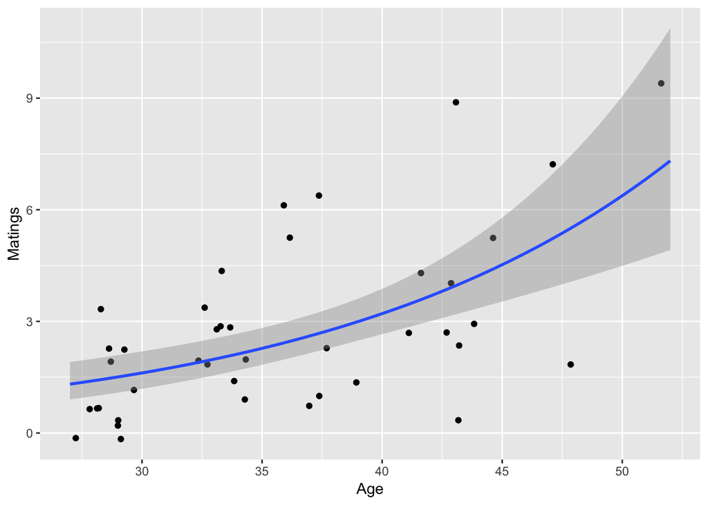

```r
# check the fitted line with log linear regression
case2201 %>% ggplot(aes(x = Age, y = Matings)) +
    geom_point(position = "jitter") +
    geom_smooth(method = "glm", method.args = list(family = "poisson"))
```

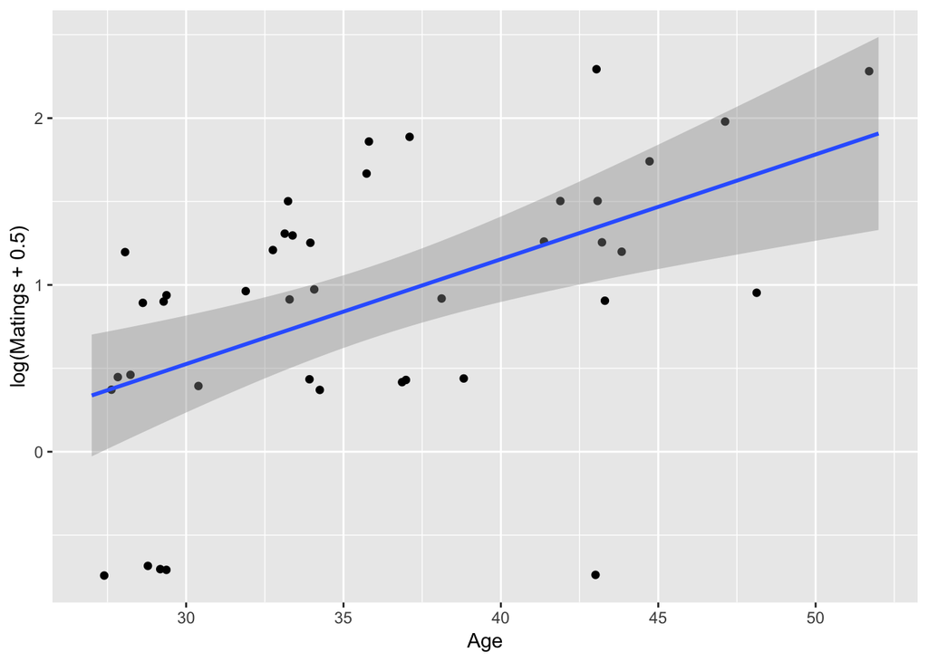

```r
# check the linearity on log scale
case2201 %>% ggplot(aes(x = Age, y = log(Matings + 0.5))) +
    geom_point(position = "jitter") +
    geom_smooth(method = "lm")
```

## Model Fitting

```r
myGlm1 <- glm(Matings ~ Age, family=poisson)
summary(myGlm1)
```

```
##
## Call:
## glm(formula = Matings ~ Age, family = poisson)
##
## Deviance Residuals:
##      Min        1Q    Median        3Q       Max
## -2.80798  -0.86137  -0.08629   0.60087   2.17777
##
## Coefficients:
##             Estimate Std. Error z value Pr(>|z|)
## (Intercept) -1.58201    0.54462  -2.905  0.00368 **
## Age          0.06869    0.01375   4.997 5.81e-07 ***
## ---
## Signif. codes:  0 '***' 0.001 '**' 0.01 '*' 0.05 '.' 0.1 ' ' 1
##
## (Dispersion parameter for poisson family taken to be 1)
##
##     Null deviance: 75.372  on 40  degrees of freedom
## Residual deviance: 51.012  on 39  degrees of freedom
## AIC: 156.46
##
## Number of Fisher Scoring iterations: 5
```

## Model Interpretation

```r
beta <- myGlm1$coef
# change in mean of Matings when increasing age by 10 years
exp(beta[2] * 10)
```

```
##    Age
## 1.9876
```

```r
# 95% confidence interval
exp(confint(myGlm1,2) * 10)
```

```
##    2.5 %   97.5 %
## 1.517065 2.602249
```

## Residuals

Standard residuals:
$$r_i = Y_i - \hat{Y}_i = Y_i - \hat{\lambda}_i$$
Pearson residuals:
$$r_i = \frac{Y_i - E(Y_i|X)}{\sqrt{Var(Y_i|X)}} = \frac{Y_i - \hat{\lambda}_i}{\sqrt{\hat{\lambda}_i}}$$
Deviance Residuals:
$$d_i = sign(y_i-\lambda_i)\sqrt{2(y_i\log(y_i/\hat{\lambda}_i)-(y_i-\hat{\lambda_i}))}$$
Deviance can be interpreted as the difference between your model’s fit and the fit of an ideal model
$$D = \sum_{i}^n d_i^2$$

- Deviance Residual and Pearson Residuals, when are they close?
- When Poisson mean is large, both residuals are approximately standard normal
- Otherwise, cannot check against standard normal

```r
# deviance residual
residuals(myGlm1) %>% head
```

```
##          1          2          3          4          5          6
## -1.6208043 -0.3619727 -0.3619727 -0.3619727  1.1649614 -1.7360551
```

```r
# Pearson residual
residuals(myGlm1, type = "pearson") %>% head
```

```
##         1         2         3         4         5         6
## -1.146082 -0.343051 -0.343051 -0.343051  1.343106 -1.227576
```

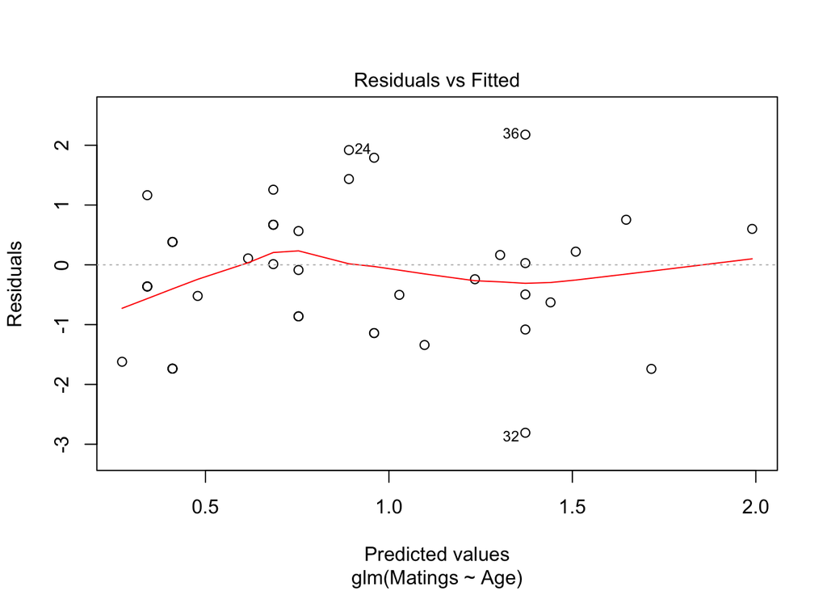

```r
# check deviance residual plot
plot(myGlm1, which = 1)
```

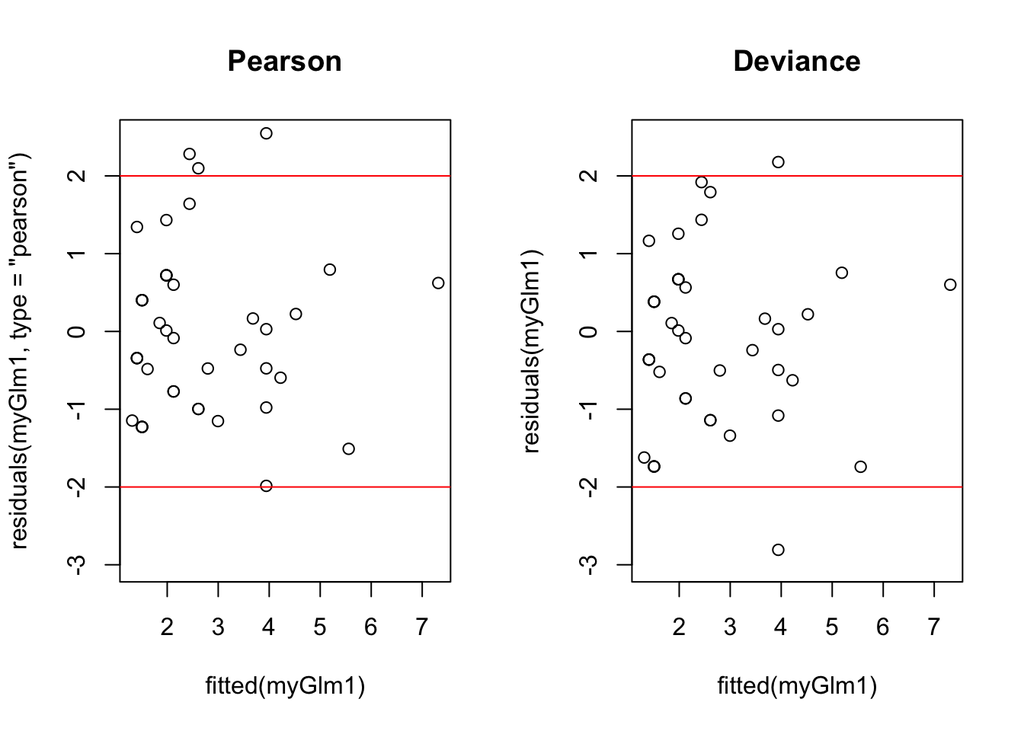

```r
# compare
par(mfrow = c(1, 2))
plot(fitted(myGlm1), residuals(myGlm1, type = "pearson"), main = "Pearson", ylim = c(-3, 2.5))
abline(h = 2, col = "red")
abline(h = -2, col = "red")
plot(fitted(myGlm1), residuals(myGlm1), main = "Deviance", ylim = c(-3, 2.5))
abline(h = 2, col = "red")
abline(h = -2, col = "red")
```

```r
par(mfrow = c(1, 1))
```

```r
detach(case2201)
```

# Overdispersion

## Loading the Data

The Del Norte Salamander (plethodon elongates) is a small (5–7 cm) salamander found among rock rubble, rock outcrops and moss-covered talus in a narrow range of northwest California. To study the habitat characteristics of the species and particularly the tendency of these salamanders to reside in dwindling old-growth forests, researchers selected 47 sites from plausible salamander habitat in national forest and parkland. Randomly chosen grid points were searched for the presence of a site with suitable rocky habitat. At each suitable site, a 7 metre by 7 metre search are was examined for the number of salamanders it contained. This data frame contains the counts of salamanders at the sites, along with the percentage of forest canopy and age of the forest in years.

```r
attach(case2202)
case2202
```

```
##    Site Salamanders PctCover ForestAge
## 1     1          13       85       316
## 2     2          11       86        88
## 3     3          11       90       548
## 4     4           9       88        64
## 5     5           8       89        43
## 6     6           7       83       368
## 7     7           6       83       200
## 8     8           6       91        71
## 9     9           5       88        42
## 10   10           5       90       551
## 11   11           4       87       675
## 12   12           3       83       217
## 13   13           3       87       212
## 14   14           3       89       398
```

[output cut: 33 more lines]

```r
case2202 %>% dim
```

```
## [1] 47  4
```

```r
logSalamanders <- log(Salamanders + .5)
logForestAge <- log(ForestAge + .5)
myMatrix <- cbind(PctCover,logForestAge,logSalamanders)
```

```r
myGlm1 <- glm(Salamanders ~ PctCover + logForestAge + PctCover:logForestAge,
              family=poisson)
summary(myGlm1) # Backward elimination...
```

```
##
## Call:
## glm(formula = Salamanders ~ PctCover + logForestAge + PctCover:logForestAge,
##     family = poisson)
##
## Deviance Residuals:
##     Min       1Q   Median       3Q      Max
## -2.9827  -1.2739  -0.7660   0.5646   3.9382
##
## Coefficients:
##                        Estimate Std. Error z value Pr(>|z|)
## (Intercept)           -0.969454   0.820929  -1.181  0.23763
## PctCover               0.029067   0.011184   2.599  0.00935 **
## logForestAge          -0.213107   0.293009  -0.727  0.46704
## PctCover:logForestAge  0.001957   0.003423   0.572  0.56741
## ---
## Signif. codes:  0 '***' 0.001 '**' 0.01 '*' 0.05 '.' 0.1 ' ' 1
##
## (Dispersion parameter for poisson family taken to be 1)
##
##     Null deviance: 190.22  on 46  degrees of freedom
## Residual deviance: 120.70  on 43  degrees of freedom
## AIC: 213.76
##
## Number of Fisher Scoring iterations: 5
```

```r
sum(residuals(myGlm1, "pearson") ^ 2) / 43
```

```
## [1] 2.820628
```

```r
myGlm2 <- update(myGlm1, ~ . - PctCover:logForestAge)
summary(myGlm2)
```

```
##
## Call:
## glm(formula = Salamanders ~ PctCover + logForestAge, family = poisson)
##
## Deviance Residuals:
##     Min       1Q   Median       3Q      Max
## -2.9560  -1.3077  -0.7245   0.5562   3.9208
##
## Coefficients:
##               Estimate Std. Error z value Pr(>|z|)
## (Intercept)  -1.372553   0.495739  -2.769  0.00563 **
## PctCover      0.034433   0.006528   5.275 1.33e-07 ***
## logForestAge -0.054700   0.100349  -0.545  0.58568
## ---
## Signif. codes:  0 '***' 0.001 '**' 0.01 '*' 0.05 '.' 0.1 ' ' 1
##
## (Dispersion parameter for poisson family taken to be 1)
##
##     Null deviance: 190.22  on 46  degrees of freedom
## Residual deviance: 121.01  on 44  degrees of freedom
## AIC: 212.07
##
## Number of Fisher Scoring iterations: 5
```

```r
sum(residuals(myGlm2, "pearson") ^ 2) / 44
```

```
## [1] 2.788119
```

```r
myGlm3 <- update(myGlm2, ~ . - logForestAge)
summary(myGlm3) # PctCover is the only explanatory variable remaining
```

```
##
## Call:
## glm(formula = Salamanders ~ PctCover, family = poisson)
##
## Deviance Residuals:
##     Min       1Q   Median       3Q      Max
## -2.9453  -1.3680  -0.7077   0.6344   3.8388
##
## Coefficients:
##              Estimate Std. Error z value Pr(>|z|)
## (Intercept) -1.481957   0.455780  -3.251  0.00115 **
## PctCover     0.032409   0.005391   6.011 1.84e-09 ***
## ---
## Signif. codes:  0 '***' 0.001 '**' 0.01 '*' 0.05 '.' 0.1 ' ' 1
##
## (Dispersion parameter for poisson family taken to be 1)
##
##     Null deviance: 190.22  on 46  degrees of freedom
## Residual deviance: 121.31  on 45  degrees of freedom
## AIC: 210.36
##
## Number of Fisher Scoring iterations: 5
```

```r
sum(residuals(myGlm3, "pearson") ^ 2) / 45
```

```
## [1] 2.730242
```

## Checking for Overdispersion

- Possible Causes
- Compare sample variance and sample averages with identical covariates (grouping)
- Deviance goodness-of-fit test after fitting a rich model (see below)
- Check outliers via residuals